# Repeated measures analysis

## Repeated measures

- More than one response *measurement* for each subject, same thing at different times
- Generalization of matched pairs (“matched triples”, etc.).
- Expect measurements on same subject to be correlated, so assumptions of independence will fail.
- *Repeated measures*. *Profile analysis* uses `Manova` (set up).
- Another approach uses *mixed models* (random effects).
- Variation: each subject does all treatments at different times (called *crossover design*).

## Packages

```r
library(car)
library(tidyverse)
library(lme4) # for mixed models later
```

## Example: histamine in dogs

- 8 dogs take part in experiment.
- Dogs randomized to one of 2 different drugs.
- Response: log of blood concentration of histamine 0, 1, 3 and 5 minutes after taking drug. (Repeated measures.)
- Data in `dogs.txt`, column-aligned.

## Read in data

```r
my_url <- "http://ritsokiguess.site/datafiles/dogs.txt"
dogs <- read_table(my_url)
dogs
```

| dog | drug | x | lh0 | lh1 | lh3 | lh5 |
| --- | --- | --- | --- | --- | --- | --- |
| A | Morphine | N | -3.22 | -1.61 | -2.30 | -2.53 |
| B | Morphine | N | -3.91 | -2.81 | -3.91 | -3.91 |
| C | Morphine | N | -2.66 | 0.34 | -0.73 | -1.43 |
| D | Morphine | N | -1.77 | -0.56 | -1.05 | -1.43 |
| E | Trimethaphan | N | -3.51 | -0.48 | -1.17 | -1.51 |
| F | Trimethaphan | N | -3.51 | 0.05 | -0.31 | -0.51 |
| G | Trimethaphan | N | -2.66 | -0.19 | 0.07 | -0.22 |
| H | Trimethaphan | N | -2.41 | 1.14 | 0.72 | 0.21 |

## Setting things up

```r
response <- with(dogs, cbind(lh0, lh1, lh3, lh5))
response
```

```
       lh0   lh1   lh3   lh5
[1,] -3.22 -1.61 -2.30 -2.53
[2,] -3.91 -2.81 -3.91 -3.91
[3,] -2.66  0.34 -0.73 -1.43
[4,] -1.77 -0.56 -1.05 -1.43
[5,] -3.51 -0.48 -1.17 -1.51
[6,] -3.51  0.05 -0.31 -0.51
[7,] -2.66 -0.19  0.07 -0.22
[8,] -2.41  1.14  0.72  0.21
```

## Another way to make response

```r
dogs %>% select(starts_with("lh")) %>%
  as.matrix() -> response
response
```

```
       lh0   lh1   lh3   lh5
[1,] -3.22 -1.61 -2.30 -2.53
[2,] -3.91 -2.81 -3.91 -3.91
[3,] -2.66  0.34 -0.73 -1.43
[4,] -1.77 -0.56 -1.05 -1.43
[5,] -3.51 -0.48 -1.17 -1.51
[6,] -3.51  0.05 -0.31 -0.51
[7,] -2.66 -0.19  0.07 -0.22
[8,] -2.41  1.14  0.72  0.21
```

## The repeated measures MANOVA

Get list of response variable names; we call them `times`. Save in data frame.

```r
times <- colnames(response)
times
```

```
[1] "lh0" "lh1" "lh3" "lh5"
```

```r
times.df <- data.frame(times=factor(times))
times.df
```

| times |
| --- |
| lh0 |
| lh1 |
| lh3 |
| lh5 |

## Fitting the model

```r
dogs.1 <- lm(response ~ drug, data = dogs)
dogs.2 <- Manova(dogs.1,
  idata = times.df,
  idesign = ~times
)
```

## The output (there is a lot)

- normally you just run

```r
summary(dogs.2)
```

and pull out what you need to answer the question.

- But you can grab just individual pieces as shown below:

```r
names(summary(dogs.2))
```

```
[1] "type"               "repeated"           "multivariate.tests"
[4] "univariate.tests"   "pval.adjustments"   "sphericity.tests"
[7] "SSPE"
```

## What there is here

- three sets of tests, for
  - times; drug; their interaction
- two *types* of test for each of these:
  - univariate; multivariate
- univariate is more powerful *if* it applies; if it doesn’t, can make adjustments to it

## Sphericity

- The thing that decides whether the univariate tests apply is called “sphericity”.
- This holds if the outcomes have equal variance (to each other) and have the same (positive) correlation across subjects.
- Tested using Mauchly’s test (part of output)
- If sphericity rejected, there are adjustments to the univariate P-values due to Huynh-Feldt and Greenhouse-Geisser. Huynh-Feldt better if responses not actually normal (safer).

## Sphericity tests

```r
summary(dogs.2)$sphericity.tests
```

```
           Test statistic  p-value
times             0.12334 0.084567
drug:times        0.12334 0.084567
```

Sphericity is not rejected; proceed to univariate tests.

## Univariate tests

```r
summary(dogs.2)$univariate.tests
```

```
            Sum Sq num Df Error SS den Df F value    Pr(>F)
(Intercept) 71.342      1  22.1026      6 19.3664  0.004565 **
drug        11.520      1  22.1026      6  3.1272  0.127406
times       26.160      3   2.2534     18 69.6546 4.215e-10 ***
drug:times   5.111      3   2.2534     18 13.6095 7.050e-05 ***
---
Signif. codes:  0 '***' 0.001 '**' 0.01 '*' 0.05 '.' 0.1 ' ' 1
```

- Significant interaction between `drug` and time: the pattern of log-histamine over time is different for the different drugs.

## If sphericity had been rejected

then we would use the H-F adjusted P-values:

```r
summary(dogs.2)$pval.adjustments
```

```
              GG eps   Pr(>F[GG])    HF eps   Pr(>F[HF])
times      0.5261798 3.744618e-06 0.6822614 1.843418e-07
drug:times 0.5261798 2.348896e-03 0.6822614 7.307096e-04
attr(,"na.action")
(Intercept)        drug
          1           2
attr(,"class")
[1] "omit"
```

## Comments

- If the interaction had not been significant:
  - cannot remove interaction with time
  - so look at univariate (or adjusted for sphericity) tests of main effects in model with non-significant interaction

## Next

- investigate interaction with graph
- but dataframe has several observations per line (“wide”).
- Plotting works with data in “long format”: one response per line.
- The responses are log-histamine at different times, labelled `lh`-something. Call them all `lh` and put them in one column, with the time they belong to labelled.

## Running `pivot_longer`, try 1

```r
dogs %>% pivot_longer(starts_with("lh"),
                      names_to = "time", values_to = "lh")
```

| dog | drug | x | time | lh |
| --- | --- | --- | --- | --- |
| A | Morphine | N | lh0 | -3.22 |
| A | Morphine | N | lh1 | -1.61 |
| A | Morphine | N | lh3 | -2.30 |
| A | Morphine | N | lh5 | -2.53 |
| B | Morphine | N | lh0 | -3.91 |
| B | Morphine | N | lh1 | -2.81 |
| B | Morphine | N | lh3 | -3.91 |
| B | Morphine | N | lh5 | -3.91 |
| C | Morphine | N | lh0 | -2.66 |
| C | Morphine | N | lh1 | 0.34 |

[output cut: 22 more lines]

## Getting the times

Not quite right: want new variable containing just number in `time`: `parse_number`. (Top 5 rows shown.)

```r
dogs %>%
  pivot_longer(starts_with("lh"),
               names_to = "timex", values_to = "lh") %>%
  mutate(time = parse_number(timex))
```

| dog | drug | x | timex | lh | time |
| --- | --- | --- | --- | --- | --- |
| A | Morphine | N | lh0 | -3.22 | 0 |
| A | Morphine | N | lh1 | -1.61 | 1 |
| A | Morphine | N | lh3 | -2.30 | 3 |
| A | Morphine | N | lh5 | -2.53 | 5 |
| B | Morphine | N | lh0 | -3.91 | 0 |

## What I did differently

- I realized that `pivot_longer` was going to produce something like `lh1`, which I needed to do something further with, so this time I gave it a temporary name `timex` (which we actually *do* use later).
- This enabled me to use the name `time` for the actual numeric time.
- This works now, so next save into a new data frame `dogs.long`.

## Saving

```r
dogs %>%
  pivot_longer(starts_with("lh"),
               names_to = "timex", values_to = "lh") %>%
  mutate(time = parse_number(timex)) -> dogs.long
```

## Comments

This says:

- Take data frame dogs, and then:
- Combine the columns `lh0` through `lh5` into one column called `lh`, with the column that each `lh` value originally came from labelled by `timex`, and then:
- Pull out numeric values in `timex`, saving in `time` and then:
- save the result in a data frame `dogs.long`.

## Interaction plot

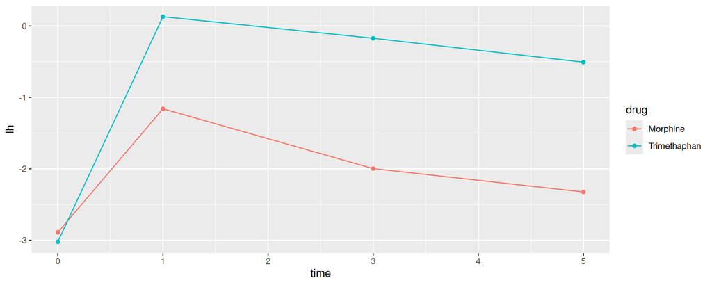

```r
ggplot(dogs.long, aes(x = time, y = lh,
                      colour = drug, group = drug)) +
  stat_summary(fun = mean, geom = "point") +
  stat_summary(fun = mean, geom = "line")
```

## Comments

- Plot mean `lh` value at each time, joining points on same drug by lines.
- drugs same at time 0
- after that, Trimethaphan higher than Morphine.
- Effect of drug not consistent over time: significant interaction.

## Take out time zero

- Lines on interaction plot would then be parallel, and so interaction should no longer be significant.
- Go back to original “wide” `dogs` data frame.

```r
response <- with(dogs, cbind(lh1, lh3, lh5)) # excl time 0
dogs.1 <- lm(response ~ drug, data = dogs)
times <- colnames(response)
times.df <- data.frame(times=factor(times))
dogs.2 <- Manova(dogs.1,
  idata = times.df,
  idesign = ~times
)
```

## Results (univariate)

```r
summary(dogs.2)$sphericity.tests
```

```
           Test statistic p-value
times             0.57597 0.25176
drug:times        0.57597 0.25176
```

```r
# summary(dogs.2)$pval.adjustments
summary(dogs.2)$univariate.tests
```

```
             Sum Sq num Df Error SS den Df F value    Pr(>F)
(Intercept) 24.2607      1  20.1874      6  7.2106   0.03628 *
drug        16.2197      1  20.1874      6  4.8207   0.07053 .
times        3.3250      2   0.7301     12 27.3251 3.406e-05 ***
drug:times   0.3764      2   0.7301     12  3.0929   0.08254 .
---
Signif. codes:  0 '***' 0.001 '**' 0.01 '*' 0.05 '.' 0.1 ' ' 1
```

## Comments

- sphericity: no problem (P-value 0.25)
- univariate test for interaction no longer significant (P-value 0.082)
- look at main effects:
  - strong significance of time, even after taking out time 0
  - actually *not* significant drug effect, despite interaction plot

## Non-significant drug effect reasonable?

- Plot *actual data*: `lh` against `days`, labelling observations by drug: “spaghetti plot”.
- Uses long data frame:
  - Plot (`time`, `lh`) points coloured by *drug*
  - connecting measurements for each *dog* by lines.
  - Hence, `group = dog`, but `colour = drug`:

```r
ggplot(dogs.long, aes(x = time, y = lh,
  colour = drug, group = dog)) +
  geom_point() + geom_line() -> g
```

## The spaghetti plot

```r
g
```

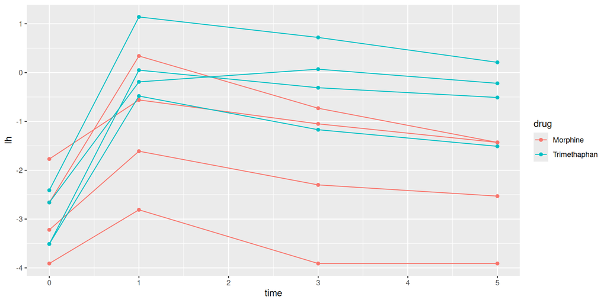

## Comments

- For each dog over time, gradual decrease in log-histamine from time 1: significant time effect after we took out time 0.
- Pattern about same for each dog, regardless of drug, hence non-significant interaction.
- Most trimethaphan dogs (blue) have higher log-histamine throughout (time 1 and after), some morphine dogs (red) have lower.
- *But* two morphine dogs have log-histamine profiles like trimethaphan dogs. This ambiguity probably why `drug` effect not quite significant.

## Mixed models

- Another way to fit repeated measures
- Subjects (on whom repeated measures taken) are *random sample of all possible subjects* (random effects)
- Times and treatments are *the only ones we care about* (fixed effects)
- Use package `lme4` function `lmer` (like `lm` in some ways)
- Uses long-format “tidy” data

## Fitting the model (uses `lme4`)

```r
# dogs.long including time zero with categorical timex
dogs.3 <- lmer(lh ~ drug * timex + (1|dog), data=dogs.long)
```

- note specification of random effect: each dog has “random intercept” that moves log-histamine up or down for that dog over all times

## What can we drop?

- using `drop1`:

```r
drop1(dogs.3, test="Chisq")
```

|  | npar | AIC | LRT | Pr(Chi) |
| --- | --- | --- | --- | --- |
|  | NA | 62.16698 | NA | NA |
| drug:timex | 3 | 84.58905 | 28.42206 | 2.961691e-06 |

- Interaction very significant. Including time zero, the pattern of log-histamine over time is different for the two drugs (as we found before).

## Omitting time zero

Let’s pretend we are working at $\alpha = 0.01$:

```r
dogs.long %>% filter(timex != "lh0") -> dogs.long.no0
dogs.4 <- lmer(lh ~ drug * timex + (1|dog), data=dogs.long.no0)
drop1(dogs.4, test = "Chisq")
```

|  | npar | AIC | LRT | Pr(Chi) |
| --- | --- | --- | --- | --- |
|  | NA | 42.1194 | NA | NA |
| drug:timex | 2 | 44.7712 | 6.651808 | 0.03594002 |

Interaction is not quite significant at $\alpha = 0.01$. So we could remove it.

## Removing the interaction

```r
dogs.5 <- update(dogs.4, . ~ . - drug:timex)
drop1(dogs.5, test = "Chisq")
```

|  | npar | AIC | LRT | Pr(Chi) |
| --- | --- | --- | --- | --- |
|  | NA | 44.77120 | NA | NA |
| drug | 1 | 47.48884 | 4.717638 | 0.0298547286 |
| timex | 2 | 62.97227 | 22.201062 | 0.0000151043 |

- Definitely an effect of time, but drug is not quite significant (at $\alpha = 0.01$).
- More or less same conclusions as from MANOVA.

## The exercise data

- 30 people took part in an exercise study.
- Each subject randomly assigned to one of two diets (“low fat” or “non-low fat”) and to one of three exercise programs (“at rest”, “walking”, “running”).
- $2\times3 = 6$ experimental treatments, and thus each one replicated $30/6=5$ times. (Two-way ANOVA, so far?)
- However, each subject had pulse rate measured at three different times (1, 15 and 30 minutes after starting their exercise), so have repeated measures.

## Reading the data

Separated by *tabs*:

```r
url <- "http://ritsokiguess.site/datafiles/exercise2.txt"
exercise.long <- read_tsv(url)
exercise.long %>% slice(1:7) # top 7 rows
```

| id | diet | exertype | pulse | time |
| --- | --- | --- | --- | --- |
| 1 | nonlowfat | atrest | 85 | min01 |
| 1 | nonlowfat | atrest | 85 | min15 |
| 1 | nonlowfat | atrest | 88 | min30 |
| 2 | nonlowfat | atrest | 90 | min01 |
| 2 | nonlowfat | atrest | 92 | min15 |
| 2 | nonlowfat | atrest | 93 | min30 |
| 3 | nonlowfat | atrest | 97 | min01 |

## Comments

- “Long format”, usually what we want.
- But for repeated measures analysis, we want *wide* format!
- Keep track of which is which:
  - `Manova` analysis: wider
  - graphs and `lmer` analysis: longer.
- `pivot_wider`.

## Making wide format

- `pivot_wider` needs: a column that is going to be split, and the column to make the values out of:

```r
exercise.long %>% pivot_wider(names_from=time,
                              values_from=pulse) -> exercise.wide
exercise.wide %>% sample_n(5) # random 5 rows
```

| id | diet | exertype | min01 | min15 | min30 |
| --- | --- | --- | --- | --- | --- |
| 22 | nonlowfat | running | 98 | 104 | 112 |
| 27 | lowfat | running | 100 | 126 | 140 |
| 28 | lowfat | running | 103 | 124 | 140 |
| 20 | lowfat | walking | 102 | 104 | 103 |
| 4 | nonlowfat | atrest | 80 | 82 | 83 |

## Setting up

- Make response variable from `min01, min15, min30`:

```r
response <- with(exercise.wide, cbind(min01, min15, min30))
```

- Predict from `diet`, `exertype`, interaction using `lm`:

```r
exercise.1 <- lm(response ~ diet * exertype,
  data = exercise.wide
)
```

## … continued

- Run this through `Manova`:

```r
times <- colnames(response)
times.df <- data.frame(times=factor(times))
exercise.2 <- Manova(exercise.1,
                     idata = times.df,
                     idesign = ~times)
```

## Sphericity tests

```r
summary(exercise.2)$sphericity.tests
```

```
                    Test statistic p-value
times                      0.92416 0.40372
diet:times                 0.92416 0.40372
exertype:times             0.92416 0.40372
diet:exertype:times        0.92416 0.40372
```

No problem with sphericity; go to univariate tests.

## Univariate tests

```r
summary(exercise.2)$univariate.tests
```

```
                    Sum Sq num Df Error SS den Df    F value
(Intercept)         894608      1   2085.2     24 10296.6595
diet                  1262      1   2085.2     24    14.5238
exertype              8326      2   2085.2     24    47.9152
diet:exertype          816      2   2085.2     24     4.6945
times                 2067      2   1563.6     48    31.7206
diet:times             193      2   1563.6     48     2.9597
exertype:times        2723      4   1563.6     48    20.9005
diet:exertype:times    614      4   1563.6     48     4.7095
                       Pr(>F)
(Intercept)         < 2.2e-16 ***
diet                0.0008483 ***
exertype            4.166e-09 ***
diet:exertype       0.0190230 *
times               1.662e-09 ***
diet:times          0.0613651 .
exertype:times      4.992e-10 ***
diet:exertype:times 0.0027501 **
---
Signif. codes:  0 '***' 0.001 '**' 0.01 '*' 0.05 '.' 0.1 ' ' 1
```

## Comments

- The three-way interaction is significant
- the effect of diet on pulse rate over time is different for the different exercise types

## Making some graphs

- Three-way interactions are difficult to understand. To make an attempt, look at some graphs.
- Plot time trace of pulse rates for each individual, joined by lines, and make *separate* plots for each `diet-exertype` combo.
- `facet_grid(diet~exertype)`: do a separate plot for each combination of diet and exercise type, with diets going down the page and exercise types going across. (Graphs are usually landscape, so have the factor `exertype` with more levels going across.)

## … continued

- `ggplot` again. Using *long* data frame:

```r
g <- ggplot(exercise.long, aes(
  x = time, y = pulse,
  group = id
)) + geom_point() + geom_line() +
  facet_grid(diet ~ exertype)
```

## The graph(s)

```r
g
```

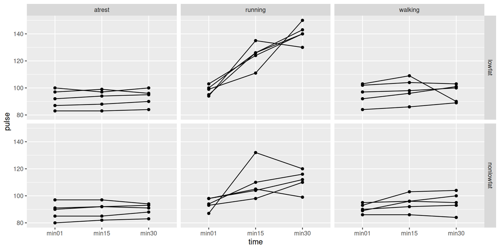

## Comments on graphs

- At rest: no change in pulse rate over time
- Walking: not much change in pulse rates over time.
- Running: overall increase in pulse rate over time, but increase stronger for `lowfat` group.
- No consistent effect of:
  - diet over all exercise groups.
  - exercise type over both diet groups.
  - time over all diet-exercise type combos.

## “Simple effects” of diet for the subjects who ran

- Looks as if there is only any substantial time effect for the runners. For them, does diet have an effect?
- Pull out only the runners from the wide data:

```r
exercise.wide %>%
  filter(exertype == "running") -> runners.wide
```

## … continued

- Create response variable and do MANOVA. Some of this looks like before, but I have different data now:

```r
response <- with(runners.wide, cbind(min01, min15, min30))
runners.1 <- lm(response ~ diet, data = runners.wide)
times <- colnames(response)
times.df <- data.frame(times=factor(times))
runners.2 <- Manova(runners.1,
  idata = times.df,
  idesign = ~times
)
```

## Sphericity tests

```r
summary(runners.2)$sphericity.tests
```

```
           Test statistic p-value
times             0.81647  0.4918
diet:times        0.81647  0.4918
```

- No problem, look at univariate tests.

## Univariate tests

```r
summary(runners.2)$univariate.tests
```

```
            Sum Sq num Df Error SS den Df   F value    Pr(>F)
(Intercept) 383522      1    339.2      8 9045.3333 1.668e-13 ***
diet          1920      1    339.2      8   45.2830 0.0001482 ***
times         4714      2   1242.0     16   30.3644 3.575e-06 ***
diet:times     789      2   1242.0     16    5.0795 0.0195874 *
---
Signif. codes:  0 '***' 0.001 '**' 0.01 '*' 0.05 '.' 0.1 ' ' 1
```

- Interaction still significant
  - dependence of pulse rate on time still different for the two diets

## How is the effect of diet different over time?

- Table of means. Only I need long data for this:

```r
runners.wide %>%
  pivot_longer(starts_with("min"),
               names_to = "time", values_to = "pulse") %>%
  group_by(time, diet) %>%
  summarize(
    mean = mean(pulse),
    sd = sd(pulse)
  ) -> summ
```

- Result of `summarize` is data frame, so can save it (and do more with it if needed).

## Interaction plot

- We went to trouble of finding means by group, so making interaction plot is now mainly easy:

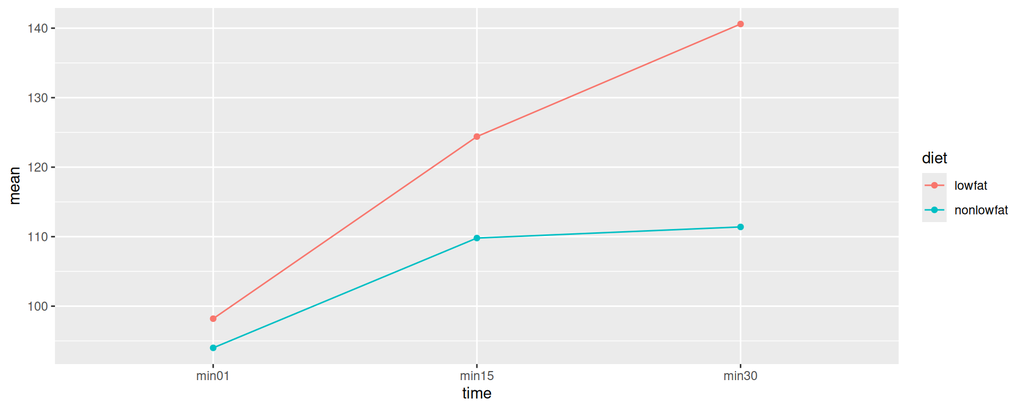

```r
ggplot(summ, aes(x = time, y = mean, colour = diet,
                 group = diet)) + geom_point() + geom_line()
```

## Comment on interaction plot

- The lines are not parallel, so there is interaction between diet and time for the runners.
- The effect of time on pulse rate is different for the two diets, even though all the subjects here were running.